# 06 - Peripheral collapse and the Area 14 refuge

Results 2.4: per-area change, historical exploitation and permanent site loss, site-level occupancy models

Sarah Ohayon, Jacob T. Dingwall, Amanda E. Bates

2026-10-01

```r
site_year <- read_csv(file.path(DERIVED, "site_year_spawn.csv"),        show_col_types = FALSE)
site_all  <- read_csv(file.path(DERIVED, "site_year_spawn_all.csv"),    show_col_types = FALSE)
site_occ  <- read_csv(file.path(DERIVED, "site_occupancy_dataset.csv"), show_col_types = FALSE)
area_expl <- read_csv(file.path(DERIVED, "area_exploitation.csv"),      show_col_types = FALSE)

PRE_YEARS    <- 1951:1983
RECENT_YEARS <- 2013:2024
```

## 1 Change in occupied sites and spawning biomass by management area

Per-area change compares the **mean annual** number of occupied sites and the **mean annual** spawn biomass in the pre-collapse era with the same quantities in recent years. Means rather than totals, so that the unequal length of the two windows does not itself create a change.

```r
window_values <- function(y0, y1) {
  site_year %>% filter(Year >= y0, Year <= y1) %>%
    group_by(StatisticalArea, Year) %>%
    summarise(n_sites = n(), biomass = sum(spawn_bio_sum), .groups = "drop") %>%   # n() = recorded sites
    group_by(StatisticalArea) %>%
    summarise(sites = mean(n_sites), biomass = mean(biomass), .groups = "drop")
}

chg <- window_values(min(PRE_YEARS), max(PRE_YEARS)) %>%
  rename(sites_pre = sites, biomass_pre = biomass) %>%
  inner_join(window_values(min(RECENT_YEARS), max(RECENT_YEARS)) %>%
               rename(sites_recent = sites, biomass_recent = biomass),
             by = "StatisticalArea") %>%
  filter(sites_pre > 0, biomass_pre > 0) %>%
  mutate(`Sites change (%)`   = 100*(sites_recent - sites_pre)/sites_pre,
         `Biomass change (%)` = 100*(biomass_recent - biomass_pre)/biomass_pre) %>%
  arrange(`Sites change (%)`)

save_tab(chg %>% mutate(across(where(is.numeric), ~round(., 1))), "per_area_change")
kable(chg %>% mutate(across(where(is.numeric), ~round(., 1))),
      caption = sprintf("Change in mean annual occupied sites and spawn biomass, %d-%d versus %d-%d",
                        min(PRE_YEARS), max(PRE_YEARS), min(RECENT_YEARS), max(RECENT_YEARS)))
```

Change in mean annual occupied sites and spawn biomass, 1951-1983 versus 2013-2024

| StatisticalArea | sites_pre | biomass_pre | sites_recent | biomass_recent | Sites change (%) | Biomass change (%) |
| --- | --- | --- | --- | --- | --- | --- |
| 18 | 8.2 | 1077.9 | 1.0 | 34.7 | -87.8 | -96.8 |
| 16 | 6.0 | 3126.2 | 1.0 | 540.3 | -83.4 | -82.7 |
| 13 | 3.8 | 4071.1 | 2.0 | 4980.2 | -47.2 | 22.3 |
| 17 | 13.2 | 11486.0 | 7.6 | 7257.9 | -42.5 | -36.8 |
| 15 | 4.4 | 2084.0 | 3.3 | 4139.2 | -24.6 | 98.6 |
| 19 | 2.2 | 192.5 | 2.0 | 169.4 | -9.1 | -12.0 |
| 14 | 8.9 | 28753.6 | 28.1 | 80804.7 | 215.4 | 181.0 |

```r
for (a in chg$StatisticalArea)
  cat(sprintf("Area %2d: sites %+.0f%%, biomass %+.0f%%\n", a,
              chg$`Sites change (%)`[chg$StatisticalArea == a],
              chg$`Biomass change (%)`[chg$StatisticalArea == a]))
```

```
## Area 18: sites -88%, biomass -97%
## Area 16: sites -83%, biomass -83%
## Area 13: sites -47%, biomass +22%
## Area 17: sites -42%, biomass -37%
## Area 15: sites -25%, biomass +99%
## Area 19: sites -9%, biomass -12%
## Area 14: sites +215%, biomass +181%
```

## 2 Historical exploitation predicts permanent site loss

Sites occupied in at least two years before the collapse are classified as **persistent** if recorded at least once during 2013-2024, or **collapsed** if absent throughout. Historical exploitation rate is an area-level, time-invariant predictor: total catch divided by total pre-fishery biomass (catch + spawn index) over 1951-1983.

A site counts as occupied in a year if spawn was **recorded** there, the same definition used by the site-level occupancy models in Section 3. Using recorded presence rather than a positive biomass value keeps the two analyses on one definition, and it is the conservative choice here: it treats records for which DFO gives no biomass estimate as observed spawning rather than as loss. Section occupancy (chapter 01) uses the same rule.

```r
hist_sites <- site_all %>%
  filter(StatisticalArea %in% BIO_AREAS, Year %in% PRE_YEARS) %>%
  group_by(StatisticalArea, LocationCode) %>%
  summarise(yrs_active_pre = n_distinct(Year), .groups = "drop") %>%
  filter(yrs_active_pre >= 2)

seen_recent <- site_all %>%
  filter(StatisticalArea %in% BIO_AREAS, Year %in% RECENT_YEARS) %>%
  distinct(StatisticalArea, LocationCode) %>% mutate(persistent = TRUE)

cd <- hist_sites %>%
  left_join(seen_recent, by = c("StatisticalArea","LocationCode")) %>%
  mutate(collapsed = as.integer(is.na(persistent))) %>%
  inner_join(area_expl, by = "StatisticalArea")

cat(sprintf("Of %d sites occupied in >= 2 years before the collapse, %d (%.0f%%) were no longer occupied during %d-%d\n",
            nrow(cd), sum(cd$collapsed), 100*mean(cd$collapsed),
            min(RECENT_YEARS), max(RECENT_YEARS)))
```

```
## Of 137 sites occupied in >= 2 years before the collapse, 77 (56%) were no longer occupied during 2013-2024
```

```r
m_expl <- glm(collapsed ~ exploit_s, data = cd, family = binomial)
OR  <- exp(coef(m_expl)[2]); p_or <- summary(m_expl)$coefficients[2, 4]
cat(sprintf("\nOdds of site loss per SD of historical exploitation: OR = %.2f, P %s\n",
            OR, fmt_p(p_or)))
```

```
##
## Odds of site loss per SD of historical exploitation: OR = 3.66, P < 0.001
```

```r
## control for historically marginal sites
m_expl2 <- glm(collapsed ~ exploit_s + scale(yrs_active_pre), data = cd, family = binomial)
OR2 <- exp(coef(m_expl2)[2]); p_or2 <- summary(m_expl2)$coefficients[2, 4]
cat(sprintf("Controlling for pre-collapse longevity: OR = %.2f, P %s (longevity itself: OR = %.2f, P %s)\n",
            OR2, fmt_p(p_or2), exp(coef(m_expl2)[3]),
            fmt_p(summary(m_expl2)$coefficients[3, 4])))
```

```
## Controlling for pre-collapse longevity: OR = 3.78, P < 0.001 (longevity itself: OR = 0.89, P = 0.580)
```

```r
print(round(summary(m_expl2)$coefficients, 4))
```

```
##                       Estimate Std. Error z value Pr(>|z|)
## (Intercept)             0.4508     0.2014  2.2379   0.0252
## exploit_s               1.3297     0.2731  4.8691   0.0000
## scale(yrs_active_pre)  -0.1145     0.2068 -0.5535   0.5800
```

```r
## exploitation varies only among the five areas, so sites within an area are not independent:
## the reported model adds a random intercept for area (Results 2.4, Methods)
m_expl_re  <- glmer(collapsed ~ exploit_s + (1|StatisticalArea), data = cd, family = binomial)
m_expl2_re <- glmer(collapsed ~ exploit_s + scale(yrs_active_pre) + (1|StatisticalArea),
                    data = cd, family = binomial)
## Fig. 4c reports the area random-intercept model
OR <- exp(fixef(m_expl_re)["exploit_s"]); p_or <- summary(m_expl_re)$coefficients["exploit_s", 4]
for (m in list(m_expl_re, m_expl2_re)) {
  ci <- exp(confint(m, method = "Wald")["exploit_s", ])
  cat(sprintf("Area random intercept: OR = %.2f (95%% CI %.2f-%.2f), P %s\n",
              exp(fixef(m)["exploit_s"]), ci[1], ci[2],
              fmt_p(summary(m)$coefficients["exploit_s", 4])))
}
```

```
## Area random intercept: OR = 4.46 (95% CI 1.88-10.60), P < 0.001
## Area random intercept: OR = 4.72 (95% CI 1.92-11.59), P < 0.001
```

```r
## assumption-free area-level check
area_loss <- cd %>% group_by(StatisticalArea) %>%
  summarise(exploit = first(exploit), pct_lost = 100*mean(collapsed),
            n_sites = n(), .groups = "drop")
rho <- suppressWarnings(cor.test(area_loss$exploit, area_loss$pct_lost,
                                 method = "spearman", exact = FALSE))
cat(sprintf("\nArea-level Spearman rho = %.2f (P %s, %d areas)\n",
            rho$estimate, fmt_p(rho$p.value), nrow(area_loss)))
```

```
##
## Area-level Spearman rho = 0.90 (P = 0.037, 5 areas)
```

```r
save_tab(area_loss %>% mutate(across(where(is.numeric), ~round(., 3))), "area_site_loss")
kable(area_loss %>% mutate(across(where(is.numeric), ~round(., 3))),
      caption = "Historical exploitation rate and proportion of historical spawning sites lost, by area")
```

Historical exploitation rate and proportion of historical spawning sites lost, by area

| StatisticalArea | exploit | pct_lost | n_sites |
| --- | --- | --- | --- |
| 13 | 0.596 | 84.615 | 13 |
| 14 | 0.111 | 30.556 | 36 |
| 15 | 0.087 | 42.105 | 19 |
| 17 | 0.500 | 55.102 | 49 |
| 18 | 0.891 | 100.000 | 20 |

## 3 Old fish and site occupancy: refuge versus periphery

Across 1977-2024, the years with test-fishery age data, the probability that a known site is occupied is modelled as a function of the proportion of old fish in that area-year. Site identity is a random intercept; **area × year** is a crossed random intercept, which is necessary because occupancy and age structure share a common temporal trend within the refuge that a single shared year effect could not remove.

```r
d <- site_occ %>%
  mutate(site   = factor(paste(StatisticalArea, LocationCode, sep = "_")),
         Year_f = factor(Year),
         area_str = factor(StatisticalArea),
         at2    = factor(if_else(StatisticalArea == 14, "refuge", "periphery"),
                         levels = c("periphery","refuge")))

cat(sprintf("%s site-years at %d sites in %d areas, %d-%d\n",
            format(nrow(d), big.mark = ","), n_distinct(d$site), n_distinct(d$area_str),
            min(d$Year), max(d$Year)))
```

```
## 8,066 site-years at 212 sites in 5 areas, 1977-2024
```

```r
m_int <- glmer(occupied ~ prop_old_s * at2 + SST_s + ONI_s + (1|site) + (1|area_str:Year_f),
               data = d, family = binomial,
               control = glmerControl(optimizer = "bobyqa", optCtrl = list(maxfun = 2e5)))
m_add <- glmer(occupied ~ prop_old_s + at2 + SST_s + ONI_s + (1|site) + (1|area_str:Year_f),
               data = d, family = binomial,
               control = glmerControl(optimizer = "bobyqa", optCtrl = list(maxfun = 2e5)))

print(round(summary(m_int)$coefficients, 4))
```

```
##                      Estimate Std. Error  z value Pr(>|z|)
## (Intercept)           -2.3478     0.1622 -14.4788   0.0000
## prop_old_s             0.3840     0.0951   4.0386   0.0001
## at2refuge              1.6027     0.2772   5.7822   0.0000
## SST_s                  0.1304     0.0797   1.6373   0.1016
## ONI_s                 -0.1418     0.0795  -1.7831   0.0746
## prop_old_s:at2refuge  -0.5284     0.1550  -3.4087   0.0007
```

```r
lrt <- anova(m_add, m_int)
p_int <- summary(m_int)$coefficients["prop_old_s:at2refuge", "Pr(>|z|)"]
cat(sprintf("\nInteraction prop_old x area type: P %s (LRT chi2 = %.2f, df = %d, P %s; dAIC = %.1f)\n",
            fmt_p(p_int), lrt$Chisq[2], lrt$Df[2], fmt_p(lrt$`Pr(>Chisq)`[2]),
            AIC(m_add) - AIC(m_int)))
```

```
##
## Interaction prop_old x area type: P < 0.001 (LRT chi2 = 11.17, df = 1, P < 0.001; dAIC = 9.2)
```

```r
b <- fixef(m_int)
cat(sprintf("Slope of prop_old on logit P(occupied): periphery %+.2f | refuge (Area 14) %+.2f\n",
            b["prop_old_s"], b["prop_old_s"] + b["prop_old_s:at2refuge"]))
```

```
## Slope of prop_old on logit P(occupied): periphery +0.38 | refuge (Area 14) -0.14
```

### Per-area models

The refuge-periphery contrast is not imposed by the classification: each area is modelled independently, with year as a crossed random intercept.

```r
per_area <- map_dfr(sort(unique(as.character(d$area_str))), function(a) {
  da <- d %>% filter(area_str == a)
  m  <- tryCatch(glmer(occupied ~ prop_old_s + SST_s + ONI_s + (1|site) + (1|Year_f),
                       data = da, family = binomial,
                       control = glmerControl(optimizer = "bobyqa",
                                              optCtrl = list(maxfun = 2e5))),
                 error = function(e) NULL)
  if (is.null(m)) return(NULL)
  cf <- summary(m)$coefficients
  tibble(Area = a, `site-years` = nrow(da), sites = n_distinct(da$site),
         `beta prop_old` = round(cf["prop_old_s","Estimate"], 3),
         SE = round(cf["prop_old_s","Std. Error"], 3),
         z  = round(cf["prop_old_s","z value"], 2),
         P  = signif(cf["prop_old_s","Pr(>|z|)"], 3))
})
save_tab(per_area, "per_area_site_occupancy_models")
kable(per_area, caption = "Per-area site-occupancy models: effect of the proportion of old fish")
```

Per-area site-occupancy models: effect of the proportion of old fish

| Area | site-years | sites | beta prop_old | SE | z | P |
| --- | --- | --- | --- | --- | --- | --- |
| 13 | 220 | 20 | 1.012 | 0.402 | 2.51 | 0.0119 |
| 14 | 3168 | 66 | -0.112 | 0.103 | -1.09 | 0.2770 |
| 15 | 483 | 23 | 0.078 | 0.152 | 0.51 | 0.6070 |
| 17 | 3948 | 84 | 0.209 | 0.168 | 1.24 | 0.2140 |
| 18 | 247 | 19 | 0.048 | 0.449 | 0.11 | 0.9150 |

### Marginal predictions

Fitted curves are population-averaged, integrated over the random-effect distribution, so they are directly comparable with observed proportions.

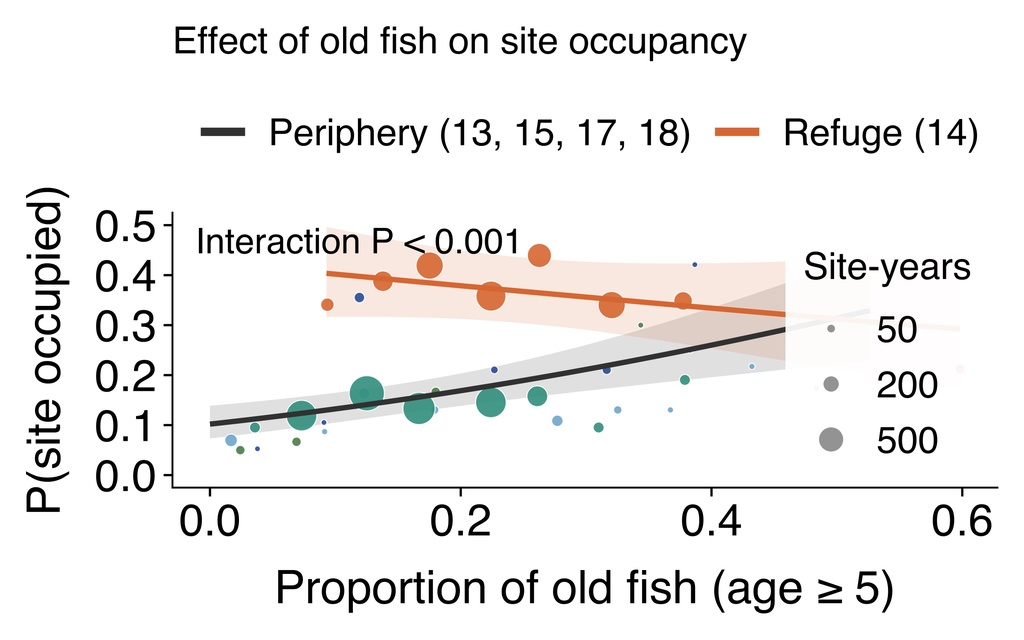

```r
gr <- map_dfr(c("periphery","refuge"), function(a) {
  s <- d %>% filter(at2 == a)
  tibble(prop_old_s = seq(min(s$prop_old_s), max(s$prop_old_s), length.out = 100),
         at2 = a, SST_s = 0, ONI_s = 0)
}) %>% mutate(at2 = factor(at2, levels = c("periphery","refuge")))

mm  <- model.matrix(~ prop_old_s * at2 + SST_s + ONI_s, gr)
eta <- as.numeric(mm %*% fixef(m_int))
se  <- sqrt(rowSums((mm %*% as.matrix(vcov(m_int))) * mm))

vc     <- as.data.frame(VarCorr(m_int))
sigRE  <- sqrt(sum(vc$vcov))
set.seed(1); rd <- rnorm(4000, 0, sigRE)
marg   <- function(e) mean(plogis(e + rd))

gr <- gr %>% mutate(prop_old = prop_old_s * sd(d$prop_old) + mean(d$prop_old),
                    fit = sapply(eta, marg),
                    lo  = sapply(eta - 1.96*se, marg),
                    hi  = sapply(eta + 1.96*se, marg),
                    curve = if_else(at2 == "refuge", "Refuge (14)",
                                    "Periphery (13, 15, 17, 18)"))

bins <- d %>% mutate(b = cut(prop_old, breaks = seq(0, 0.65, 0.05), include.lowest = TRUE)) %>%
  group_by(area_str, b) %>%
  summarise(prop_old = mean(prop_old), P = mean(occupied), n = n(), .groups = "drop") %>%
  filter(n >= 8)

curve_cols <- c("Periphery (13, 15, 17, 18)" = "grey25", "Refuge (14)" = "#E07B3F")

## Shared look for the four Figure 4 panels: same scale of type as Figures 1-2,
## with more clearance between each axis and its title than theme_science gives.
theme_fig4 <- theme_science +
  theme(plot.title   = element_text(size = 21, face = "bold",
                                    margin = margin(b = 14)),
        axis.title.x = element_text(size = 26, margin = margin(t = 14)),
        axis.title.y = element_text(size = 26, margin = margin(r = 14)),
        axis.text    = element_text(size = 25, colour = "black"),
        legend.text  = element_text(size = 17),
        legend.title = element_text(size = 17),
        legend.key   = element_blank(),
        legend.background = element_rect(fill = alpha("white", 0.7), colour = NA))

p_occ <- ggplot() +
  geom_ribbon(data = gr, aes(prop_old, ymin = lo, ymax = hi, fill = curve), alpha = 0.15) +
  geom_point(data = bins, aes(prop_old, P, size = n, fill = area_str),
             shape = 21, colour = "white", stroke = 0.4, alpha = 0.9) +
  geom_line(data = gr, aes(prop_old, fit, colour = curve), linewidth = 1.4) +
  scale_fill_manual(values = c(area_cols, curve_cols), guide = "none") +
  scale_colour_manual(values = curve_cols, name = NULL) +
  ## the bins are counts of site-years, so the size key says so
  scale_size_area(name = "Site-years", max_size = 9, breaks = c(50, 200, 500)) +
  ## top-left: the size key holds the bottom-right corner
  annotate("text", x = -Inf, y = Inf, hjust = -0.07, vjust = 1.6, size = 7,
           fontface = "bold", label = sprintf("Interaction P %s", fmt_p(p_int))) +
  coord_cartesian(ylim = c(0, 0.5)) +
  labs(x = "Proportion of old fish (age ≥ 5)", y = "P(site occupied)",
       title = "Effect of old fish on site occupancy") +
  theme_fig4 +
  theme(legend.position = c(0.99, 0.01), legend.justification = c(1, 0),
        legend.box = "vertical", legend.box.just = "right",
        ## points sit in this corner too, so the key needs a solid ground
        legend.background = element_rect(fill = alpha("white", 0.93), colour = NA),
        legend.text  = element_text(size = 21),
        legend.title = element_text(size = 21),
        legend.key.size = unit(1.1, "cm"),
        legend.spacing.y = unit(2, "pt")) +
  guides(colour = guide_legend(order = 1, position = "top",
                               override.aes = list(linewidth = 2.2)),
         ## stacked, not horizontal: a row of three keys is wide enough to sit
         ## over the refuge confidence band
         size   = guide_legend(order = 2, title.position = "top",
                               override.aes = list(fill = "grey60", colour = "white")))
save_fig(p_occ, "Fig4d_site_occupancy_refuge_periphery", width = 10, height = 8)
p_occ
```

## 4 Figure 4 - panels a-c

Panel **d** is built in Section 3 above. The three remaining panels are assembled here from `site_year` (a), `chg` (b) and `cd` / `area_loss` (c), so the figure and the statistics come from the same objects.

```r
## ---- a  Spawning sites, pre-collapse versus recent --------------------------
PERIOD_LEVELS <- c(sprintf("Pre-collapse (≤%d)", max(PRE_YEARS)),
                   sprintf("Recent (%d-%d)", min(RECENT_YEARS), max(RECENT_YEARS)))

## Bubbles are mean ANNUAL spawn: each site's total over the window divided by the
## length of the window, so years without spawn count as zeros. Dividing instead by
## the number of years a site actually spawned - which is what a plain mean() does,
## since site_year has no rows for empty years - makes a site that spawned once in
## twelve years draw the same bubble as one that spawns every year. In the recent
## window 37% of peripheral sites spawned in a single year, so that version showed a
## larger median peripheral bubble now (410 t) than before the collapse (204 t), the
## opposite of the truth: the periphery fell from 46% of annual spawn to 12%.
## A site is mapped only if it was in regular use within the period: at least 2 spawn years
## inside some 5-year window. Without this, a site that spawned once in twelve years draws the
## same kind of dot as one used every year, which overstates how much of the periphery is still
## in use. Biomass is unaffected (the rule drops only sparsely used sites, which carry little).
in_regular_use <- function(years, win_years, min_yrs = 2, win = 5) {
  ys <- sort(unique(years))
  if (!length(ys)) return(FALSE)
  starts <- min(win_years):(max(win_years) - win + 1)
  any(vapply(starts, function(st) sum(ys >= st & ys <= st + win - 1) >= min_yrs, logical(1)))
}

map_sites <- site_year %>%
  filter(!is.na(Longitude), !is.na(Latitude)) %>%
  mutate(period = case_when(Year %in% PRE_YEARS    ~ PERIOD_LEVELS[1],
                            Year %in% RECENT_YEARS ~ PERIOD_LEVELS[2],
                            TRUE ~ NA_character_)) %>%
  filter(!is.na(period)) %>%
  group_by(period, StatisticalArea, LocationCode, Longitude, Latitude) %>%
  summarise(total_bio = sum(spawn_bio), n_yrs_spawned = n_distinct(Year),
            regular = in_regular_use(Year, if (period[1] == PERIOD_LEVELS[1]) PRE_YEARS else RECENT_YEARS),
            .groups = "drop") %>%
  filter(regular) %>%
  mutate(window_yrs = if_else(period == PERIOD_LEVELS[1],
                              length(PRE_YEARS), length(RECENT_YEARS)),
         mean_bio   = total_bio / window_yrs,
         period     = factor(period, levels = PERIOD_LEVELS),
         area_f     = factor(as.character(StatisticalArea), levels = names(area_cols)))

map_sites %>% group_by(period) %>%
  summarise(sites = n(), annual_t = round(sum(mean_bio)),
            periphery_pct = round(100*sum(mean_bio[StatisticalArea != 14])/sum(mean_bio), 1),
            .groups = "drop") %>% print()
```

```
## # A tibble: 2 × 4
##   period               sites annual_t periphery_pct
##   <fct>                <int>    <dbl>         <dbl>
## 1 Pre-collapse (≤1983)   159    35243          41.8
## 2 Recent (2013-2024)      66    86086           8.2
```

[figure not shown]

```r
coast <- tryCatch(
  rnaturalearth::ne_countries(scale = "large", returnclass = "sf"),
  error = function(e) rnaturalearth::ne_countries(scale = "medium", returnclass = "sf"))

## Management-area outlines, dissolved from the DFO section polygons. StatArea is
## a zero-padded character field in the shapefile, hence the numeric coercion.
## Sections 161-165 do not share exact edges, so dissolving Area 16 leaves a sliver gap that
## survives as an interior ring and is drawn as a line across the area. No management area has
## a real hole, so keep exterior rings only.
drop_holes <- function(g) {
  if (inherits(g, "MULTIPOLYGON")) st_multipolygon(lapply(g, function(pp) pp[1]))
  else st_polygon(g[1])
}

areas_sf <- tryCatch({
  x <- st_read(F_SECT, quiet = TRUE) %>%
    st_make_valid() %>%
    mutate(StatisticalArea = suppressWarnings(as.numeric(StatArea))) %>%
    filter(StatisticalArea %in% OCC_AREAS) %>%
    group_by(StatisticalArea) %>% summarise(.groups = "drop") %>%
    st_make_valid()
  st_geometry(x) <- st_sfc(lapply(st_geometry(x), drop_holes), crs = st_crs(x))
  x %>%
    st_transform(4326) %>%
    mutate(area_f = factor(as.character(StatisticalArea), levels = names(area_cols)))
}, error = function(e) NULL)

## Fixed map frame (the Aug 2026 extent), so that all nine management areas stay in view after
## non-SoG spawn records were excluded; a data-driven frame would crop Areas 13, 28 and 29.
xlim_m <- c(-126.10, -122.60)
ylim_m <- c(48.18, 51.03)

p4a <- ggplot() +
  geom_sf(data = coast, fill = "grey88", colour = "grey60", linewidth = 0.3) +
  {if (!is.null(areas_sf))
     geom_sf(data = areas_sf, aes(colour = area_f), fill = NA, linewidth = 0.7)} +
  geom_point(data = map_sites,
             aes(Longitude, Latitude, size = mean_bio, colour = area_f), alpha = 0.75) +
  scale_size_area(name = "Mean annual spawn (t)", max_size = 9,
                  breaks = c(1000, 4000, 8000),
                  labels = label_number(big.mark = ",")) +
  scale_colour_manual(values = area_cols, name = "Management area") +
  scale_x_continuous(breaks = seq(-126, -123, by = 1)) +
  coord_sf(xlim = xlim_m, ylim = ylim_m, expand = FALSE) +
  facet_wrap(~ period, nrow = 1, axes = "all") +
  labs(x = NULL, y = NULL, title = "Spatial collapse of spawning from periphery to core refuge") +
  theme_fig4 +
  theme(strip.background = element_blank(),
        strip.text       = element_text(size = 27),
        panel.spacing.x  = unit(10, "lines"),            # clear gap between the two maps
        ## water tinted so the coastline reads as land against sea
        panel.background = element_rect(fill = "#EAF3F8", colour = NA),
        panel.border     = element_rect(fill = NA, colour = "grey40"),
        ## only the size key is kept, inside the recent map where the frame is empty;
        ## areas are identified by their coloured outlines, so that key is redundant
        legend.position  = c(0.965, 0.955), legend.justification = c(1, 1),
        legend.text      = element_text(size = 19),
        legend.title     = element_text(size = 19),
        legend.margin    = margin(0, 0, 0, 0),
        legend.background = element_blank(), legend.key = element_blank()) +
  guides(colour = "none", size = guide_legend(ncol = 1))

## ---- b  Percent change in sites and biomass, by area ------------------------
chg_long <- chg %>%
  transmute(area_f = factor(as.character(StatisticalArea), levels = names(area_cols)),
            Sites = `Sites change (%)`, Biomass = `Biomass change (%)`) %>%
  pivot_longer(c(Sites, Biomass), names_to = "metric", values_to = "pct") %>%
  mutate(metric = factor(metric, levels = c("Sites", "Biomass")),
         ## Area 28 has no pre-collapse spawn so it is filtered out of `chg`,
         ## but the factor level survives and draws an empty labelled row
         area_f = fct_drop(fct_reorder(area_f, pct, .fun = min)))

p4b <- ggplot(chg_long, aes(pct, area_f, fill = area_f, alpha = metric)) +
  geom_col(position = position_dodge(width = 0.75), width = 0.7) +
  geom_vline(xintercept = 0, colour = "grey25", linewidth = 0.6) +
  ## Value at the end of each bar, pushed outward so it never sits on the bar.
  ## group = metric is required: geom_col groups by interaction(area_f, metric)
  ## via its fill and alpha aesthetics, but geom_text has neither, so without an
  ## explicit group the two labels of a pair collapse onto the same line.
  geom_text(aes(label = sprintf("%+.0f%%", pct), group = metric,
                hjust = if_else(pct >= 0, -0.18, 1.18)),
            position = position_dodge(width = 0.75),
            size = 9, alpha = 1, colour = "grey20", show.legend = FALSE) +
  scale_fill_manual(values = area_cols, guide = "none") +
  scale_alpha_manual(values = c(Sites = 1, Biomass = 0.45), name = NULL,
                     breaks = c("Biomass", "Sites"),
                     labels = c("Biomass", "Occupied sites")) +
  ## room on both sides for the labels
  scale_x_continuous(labels = label_number(suffix = "%"),
                     expand = expansion(mult = c(0.26, 0.30))) +
  scale_y_discrete(labels = function(x) paste("Area", x)) +
  labs(x = "Change from pre-collapse to recent", y = "Management\narea",
       title = "Change in biomass and number of spawning sites") +
  theme_fig4 +
  ## the y title reads as a column heading above the topmost area, not rotated beside it
  theme(axis.title.y = element_text(angle = 0, hjust = 1, vjust = 1.02, size = 22,
                                    margin = margin(r = -58, l = 0)),
        plot.margin  = margin(t = 16, r = 40, b = 6, l = 2),
        legend.text  = element_text(size = 21),
        legend.key.size = unit(1.1, "cm"),
        legend.position = c(0.80, 0.02), legend.justification = c(1, 0)) +
  ## one column, Biomass above Occupied sites, so the key is tall not wide
  guides(alpha = guide_legend(ncol = 1, reverse = FALSE,
                              override.aes = list(fill = "grey35")))

## ---- c  Site loss against historical exploitation ---------------------------
## The fitted line is the site-level logistic model; the points are areas. The
## grid is built on the standardised predictor the model uses, then mapped back
## to the raw exploitation rate for the axis via the exact linear relation.
back_tf   <- lm(exploit ~ exploit_s, data = cd)
expl_grid <- tibble(exploit_s = seq(min(cd$exploit_s), max(cd$exploit_s), length.out = 200))
pr        <- predict(m_expl, newdata = expl_grid, se.fit = TRUE, type = "link")
expl_grid <- expl_grid %>%
  mutate(exploit = predict(back_tf, expl_grid),
         fit = plogis(pr$fit),
         lo  = plogis(pr$fit - 1.96*pr$se.fit),
         hi  = plogis(pr$fit + 1.96*pr$se.fit))

area_loss_p <- area_loss %>%
  mutate(area_f = factor(as.character(StatisticalArea), levels = names(area_cols)),
         prop_lost = pct_lost/100)

p4c <- ggplot() +
  geom_ribbon(data = expl_grid, aes(exploit, ymin = lo, ymax = hi),
              fill = "grey70", alpha = 0.30) +
  geom_line(data = expl_grid, aes(exploit, fit), colour = "grey15", linewidth = 1.3) +
  geom_point(data = area_loss_p,
             aes(exploit, prop_lost, fill = area_f, size = n_sites),
             shape = 21, colour = "white", stroke = 0.6) +
  ggrepel::geom_text_repel(data = area_loss_p,
             aes(exploit, prop_lost, label = StatisticalArea),
             size = 7.5, fontface = "bold", seed = 1,
             box.padding = 0.8, min.segment.length = 0.2) +
  ## model statistics, top-left: the fitted curve rises left to right, so this
  ## corner stays clear of both the line and its confidence band
  annotate("text", x = -Inf, y = Inf, hjust = -0.08, vjust = 1.35, size = 7,
           lineheight = 1.15, colour = "grey15",
           label = sprintf("OR = %.2f, P %s\nSpearman ρ = %.2f",
                           OR, fmt_p(p_or), rho$estimate)) +
  scale_fill_manual(values = area_cols, guide = "none") +
  scale_size_area(name = "Historical sites", max_size = 11) +
  scale_x_continuous(labels = percent_format(accuracy = 1),
                     expand = expansion(mult = c(0.06, 0.08))) +
  scale_y_continuous(labels = percent_format(accuracy = 1),
                     expand = expansion(mult = c(0.08, 0.18))) +
  labs(x = sprintf("Historical exploitation rate, %d-%d", min(PRE_YEARS), max(PRE_YEARS)),
       y = "Historical spawning sites lost",
       title = "Effect of historical exploitation on site collapse") +
  theme_fig4 +
  theme(legend.position = c(0.99, 0.02), legend.justification = c(1, 0),
        legend.text  = element_text(size = 21),
        legend.title = element_text(size = 21),
        legend.key.size = unit(1.1, "cm")) +
  ## the points are white-outlined and get their fill from the area palette, so
  ## the size keys need an explicit fill or they render white on white
  guides(size = guide_legend(override.aes = list(fill = "grey55", colour = "grey25")))

save_fig(p4a, "Fig4a_spawn_sites_two_periods", width = 16, height = 9)
save_fig(p4b, "Fig4b_percent_change_by_area",  width = 11, height = 14)
save_fig(p4c, "Fig4c_site_loss_vs_exploitation", width = 10, height = 8)

## Layout mirrors the hand-assembled version: the two maps span the top left, the
## per-area bars run full height on the right, the two model panels sit beneath
## the maps. Tags are supplied in panel order a, c, d, b to match that geometry.
fig4 <- ((p4a / (p4c | p_occ)) + plot_layout(heights = c(1.3, 1)) | p4b) +
  plot_layout(widths = c(2.1, 1)) +
  plot_annotation(tag_levels = list(c("a","c","d","b"))) &
  theme(plot.tag = element_text(size = 34, face = "bold"))

## Type sizes are fixed in points, so the composite is kept near the size the
## panels were tuned at; a much larger canvas would shrink all text relative to it.
save_fig(fig4, "Figure4_spatial_collapse_to_refuge", width = 28, height = 19)

## Same layout with no a/b/c/d tags: panel letters are added by hand in Inkscape.
## Panel titles are dropped here (the caption carries them) because at composite size the
## fixed point sizes make adjacent titles collide, and the canvas is enlarged so that the
## facet strips, axis labels and bar labels are not clipped.
fig4_untagged <- ((p4a / (p4c | p_occ)) + plot_layout(heights = c(1.3, 1)) | p4b) +
  plot_layout(widths = c(2.1, 1)) & labs(title = NULL)
save_fig(fig4_untagged, "Figure4_four_panels_untagged", width = 28, height = 19)
fig4
```